# Density Estimation

**Methods**:

- Histogram
- Mixture Model
- Kernel Density Estimation
- Nearest Neighbour Kernel Density Estimation

```
import sys, os
from pyprojroot import here
root = here(project_files=[".here"])
sys.path.append(str(here()))

# NUMPY SETTINGS
import numpy as np
np.set_printoptions(precision=3, suppress=True)

# MATPLOTLIB Settings
import matplotlib as mpl
import matplotlib.pyplot as plt
%matplotlib inline
%config InlineBackend.figure_format = 'retina'

# SEABORN SETTINGS
import seaborn as sns
sns.set_context(context='talk',font_scale=0.7)
# sns.set(rc={'figure.figsize': (12, 9.)})
# sns.set_style("whitegrid")

# PANDAS SETTINGS
import pandas as pd
pd.set_option("display.max_rows", 120)
pd.set_option("display.max_columns", 120)

# LOGGING SETTINGS
import sys
import logging
logging.basicConfig(
    level=logging.INFO,
    stream=sys.stdout,
    format='%(asctime) s:%(levelname) s:%(message)s '
)
logger = logging.getLogger()
#logger.setLevel(logging.INFO)

%load_ext autoreload
%autoreload 2
```

```
The autoreload extension is already loaded. To reload it, use:
  %reload_ext autoreload
```

## Data

```
def make_bimodal_data(n_samples: int, f: float=0.3, seed: int=1) -> np.ndarray:
    rand = np.random.RandomState(seed)
    x = rand.randn(n_samples)
    x[int(f * n_samples):] += 5
    return x
```

## Histogram Estimation

This is a kind of local density estimation. In histograms, we use *nearby* points to estimate the density. This works by dividing the space into $N$-bins and we can approximate the density at the center of each bin by the fraction of points in the training data that falls into the corresponding bin.

$$p_h(x) = \frac{k}{N V} = \frac{n_i}{N \Delta_i}$$

where:

- $k$ is the number of points in a region
- $V$ - volume of region
- $N$ - total number of datapoints

So if $x$ is close to many points, that's a high probability of x.

1. Count # of datapoints

```
n_samples = 100
x = make_bimodal_data(n_samples)

fig, ax = plt.subplots()
hist = ax.hist(x, bins=10, density=True)
pts = ax.plot(x, np.full_like(x, -0.01), '|k', markeredgewidth=1)
plt.show()
```

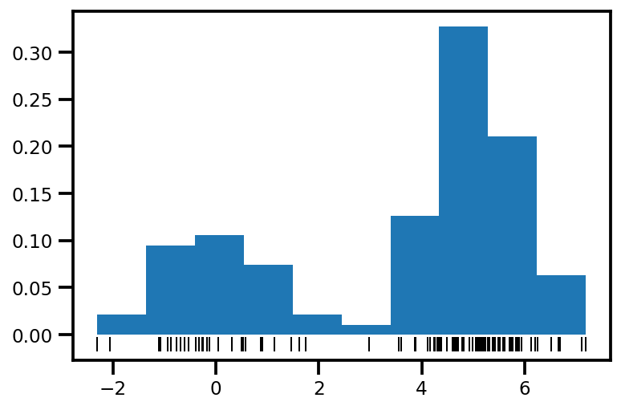

### Bin Estimation

- scott
- knuth
- freedman
- bayesian blocks
  - [Studies in Astronomical Time Series Analysis. VI. Bayesian Block Representations](https://ui.adsabs.harvard.edu/abs/2013ApJ...764..167S/abstract) - Scargle et. al. (2012)
- sqrt

**Examples**:

- Astropy Bin Estimation - [Demo](https://docs.astropy.org/en/stable/visualization/histogram.html)
- AstroML 1D Density Estimators - [Demo](https://www.astroml.org/book_figures/chapter6/fig_GMM_density_estimation.html)

```
from astropy import stats as astats

methods = [
    'scott',
    'auto',
    'sqrt'
]
```

```
x_plot = np.linspace(-4, 10, 1_000)

fig, ax = plt.subplots()
for imethod in methods:
    # calculate bin edges
#     bins = np.histogram_bin_edges()
    ax.hist(x, bins=imethod, alpha=0.3, density=True, label=f"{imethod}")

bins_bayes = astats.bayesian_blocks(x, fitness='events', p0=0.01)
hist = ax.hist(x, bins=bins_bayes, density=True, alpha=0.3, label="Bayes Blocks")
ax.legend()
ax.set(
    xlabel=r'$x$',
    ylabel=r'$p(x)$'
)
plt.show()
```

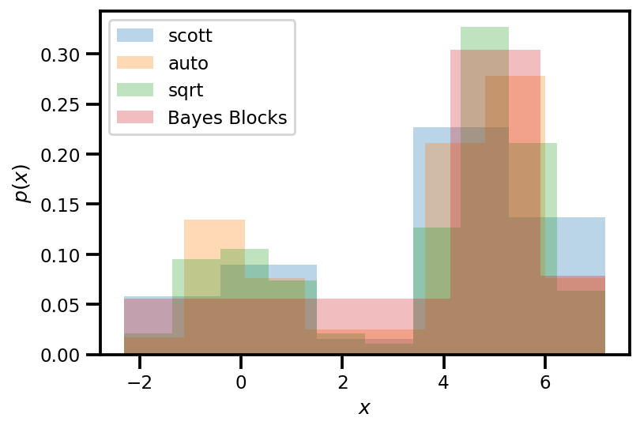

```
hist, _ = np.histogram(x, bins=bins_bayes, density=True)

for imethod in methods:
    # calculate bin edges
#     bins = np.histogram_bin_edges()
    hist, _ = np.histogram(x, bins=imethod, density=True)

    print(stats.entropy(hist), - (hist * np.log(np.abs(hist))).sum())

bins_bayes = astats.bayesian_blocks(x, fitness='events', p0=0.01)
hist, _ = np.histogram(x, bins=bins_bayes, density=True)
print(stats.entropy(hist), - (hist * np.log(np.abs(hist))).sum())
```

```
1.3623759191968534 1.0555752005368166
1.7277094340769326 1.6006573458595894
1.9438450128427205 1.9934348495405312
0.8238249779913889 0.7227628905498504
```

**Cons**:

- Sensitive to the # of bins
- Shape of the dist. depends on the starting position of the bins
  - for multivariate data, this can also depend on the orientation.
- discontinuities are not due to underlying density, they are an artifact of the bin locations
  - harder to grasp the structure of the data with the discontinuities
- curse of dimensionality: the # of bins grows exponentially with the # of dimensions
  - need a large number of samples for higher dimensions
- only suitable for rapid viz of results in one or two dimensions

## Widths

$$p(x) \approx \frac{k}{NV}$$

where:

- $V$ is the volume surrounding $x$
- $k$ is the number of samples inside the volume
- $N$ is the number of examples

## Mixture Models

```
from sklearn.mixture import GaussianMixture
```

```
stats.entropy(gmm_clf.score_samples(x_eval.reshape(-1, 1)))
```

```
gmm_clf = GaussianMixture(n_components=5).fit(x.reshape(-1, 1))

x_dens = gmm_clf.score_samples(x_eval.reshape(-1, 1))
```

```
fig, ax = plt.subplots()
# hist = ax.hist(x, bins=10, density=True)
ax.fill_between(x_eval, np.exp(x_dens), alpha=0.5)
pts = ax.plot(x, np.full_like(x, -0.01), '|k', markeredgewidth=1)
plt.show()
```

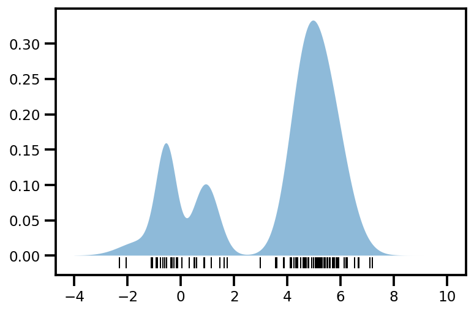

### Kernel Density Estimation

In kernel density estimation, we choose a fixed value of the volumne $V$ and determine the $k$ from the data. This can be shown that the estimator converges to the true probability density as $N \rightarrow \infty$ if $V$ shrinks with $N$ and $k$ grows with $N$ appropropriately.

$$k = \sum_{n=1}^N K\left( \frac{x- x^n}{\lambda} \right)$$

```
def kerneldensity(y, x, bandwidth, kernel):
    """kernel density"""
    # calculate bandwidth
    h = bandwidth(y)

    # calculate kernel
    k = kernel((x - y[:, None]) / h)
    print(k.shape)
    k /= h
    k = np.sum(k, axis=0)
    print(k.shape)
    return k / y.shape[0]
```

```
k = kerneldensity(x, x_eval, silverman, gaussian)
```

```
(100, 1000)
(1000,)
```

### Kernels

#### Gaussian Kernel

$$ K(x) = \frac{1}{\sqrt{2\pi}} \exp\left(-\frac{1}{2}x^2 \right) $$

```
def gaussian(u):
    return 1 / np.sqrt(2 * np.pi) * np.exp(- u**2 / 2)
```

#### Epanechnikov Kernel

We know that the Epanechnikov kernel has the lowest (asymptotic) mean-squared error.

```
def epanechnikov(u):
#     return np.where(np.abs(u) <= np.sqrt(5), 3/(4*np.sqrt(5)) * (1 - u**2 / 5.0), 0)
    return (3. / 4.) * np.max(1 - u**2, 0.0)
```

#### Estimating the Length Scale

```
def silverman(x):
    n_samples = x.shape[0]

    # calculate the interquartile range
    iqr = np.subtract(*np.percentile(x, [75, 25]))

    # lengthscale
    h = 0.9 * np.min([x.std(ddof=1), iqr / 1.34]) * n_samples ** -0.2
    return h
```

```
from scipy import stats

# # get evaluation grid
x_eval = np.linspace(-4, 10, 1_000)
# logging.info(f"x: {x_eval.shape}")

# # get pdf est for each
# density_grid = np.array([stats.norm(xi).pdf(x_eval) for xi in x])
# logging.info(f"K: {density_grid.shape}")

# density = np.sum(density_grid, axis=0)
# logging.info(f"K: {density.shape}")

density_ = kerneldensity(x, x, silverman, epanechnikov)
density = kerneldensity(x, x_eval, silverman, epanechnikov)

print(
    stats.entropy(density_),
    stats.entropy(density)
)


fig, ax = plt.subplots()
# hist = ax.hist(x, bins=10, density=True)
ax.fill_between(x_eval, density, alpha=0.5)
pts = ax.plot(x, np.full_like(x, -0.01), '|k', markeredgewidth=1)
ax.set(
    xlabel=r'$x$',
    ylabel=r'$p(x)$'
)
plt.show()
```

```
(100, 100)
(100,)
(100, 1000)
(1000,)
4.5043625235270195 6.485400324068893
```

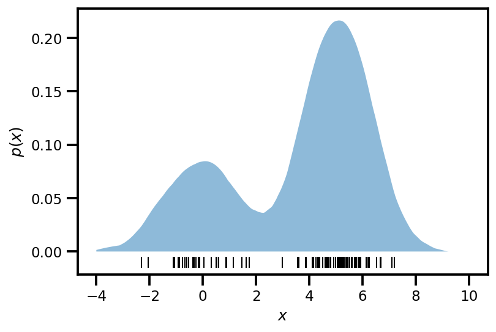

**Advantages**:

- Fast at Training Time

**Disadvantages**

- Slow at Test Time
  - High memory footprint
- Sensitive to kernel bandwidth

### K-Nearest Neighbours

This method fixes the number of nearby points $k$,

$$p_\text{kNN}(x) = \frac{k}{N}\frac{1}{V_d \cdot R_k^d(x)}$$

where:

- $k$-th nearest neighbour - (fixed)
- $V_d \cdot R_k^d(x)$ - Volume of a $d$-dimensional vall with radius being $R_k(x)$.
  - $V_d = \frac{\pi^{d/2}}{\Gamma(\pi/2+1)}$

We choose a fixed value of $k$ and determine the corresponding volumne $V$ from the data. Again, this can be shown that the estimator converges to the true probability density as $N \rightarrow \infty$ if $V$ shrinks with $N$ and $k$ grows with $N$ appropropriately.

```
k_neighbours = 5

diff = np.absolute(x - x[:, np.newaxis])
logging.info(f"diff: {diff.shape}")
diffsort = np.sort(diff, axis=0)
h = diffsort[k_neighbours, :]

plt.hist(h)
```

[output not shown]

[figure not shown]

$$ p(x) = \sum_{i=1}^k \frac{1}{r_i^n} $$

```
from sklearn.neighbors import NearestNeighbors
from scipy import special

def n_volume(r, n):
    """compute the n-volume of a sphere of radius r in n dimensions"""
    return np.pi ** (0.5 * n) / special.gamma(0.5 * n + 1) * (r ** n)
```

```
k = 10

# initialize nearest neighbour estimator
knn_clf = NearestNeighbors(n_neighbors=k)

#fit estimator
knn_clf.fit(x.reshape(-1,1))
n_samples = x.shape[0]

# query to get neighbours
dist, ind = knn_clf.kneighbors(x_eval.reshape(-1,1))

# n_samples = x_eval.shape[0]

# calculate the density
k = float(k)
n_dim = 1
# density_knn = float(k) / n_volume(dist[:, -1], 1)


density_knn = (k * (k + 1) * 0.5 / n_volume(1, n_dim) / (dist ** n_dim).sum(1))
density_knn /= n_samples
```

```
fig, ax = plt.subplots()
# hist = ax.hist(x, bins=10, density=True)
ax.fill_between(x_eval, density_knn, alpha=0.5)
pts = ax.plot(x, np.full_like(x, -0.01), '|k', markeredgewidth=1)
plt.show()
```

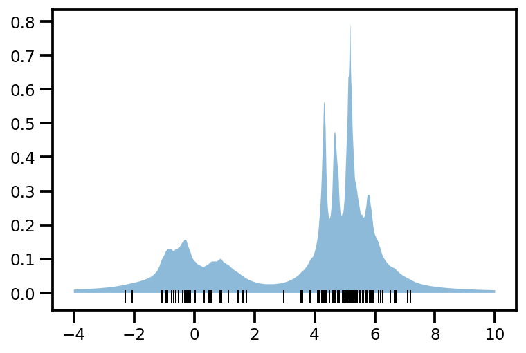

```
from sklearn.neighbors import KernelDensity
```

* [Entropy](https://stackoverflow.com/questions/57325537/compute-entropy-of-a-set-of-points)

```
sk_clf = KernelDensity().fit(x.reshape(-1,1))

x_dens = sk_clf.score_samples(x_eval.reshape(-1, 1))


log_p = sk_clf.score_samples(x_eval.reshape(-1,1))  # returns log(p) of data sample
p = np.exp(log_p)                # estimate p of data sample
entropy = -np.sum(p*log_p)       # evaluate entropy
print(entropy)
```

```
160.2927308434686
```

```
fig, ax = plt.subplots()
# hist = ax.hist(x, bins=10, density=True)
ax.fill_between(x_eval, np.exp(x_dens), alpha=0.5)
pts = ax.plot(x, np.full_like(x, -0.01), '|k', markeredgewidth=1)
plt.show()
```

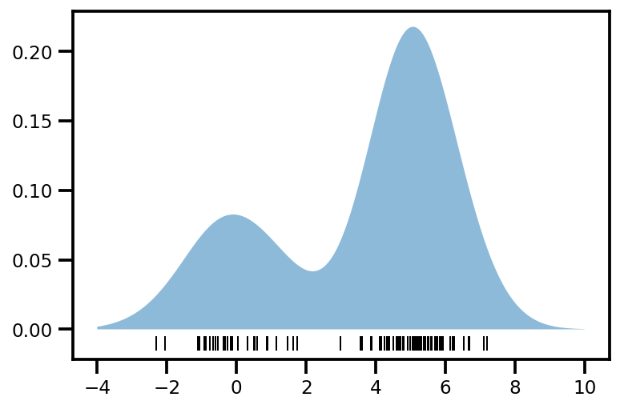

**Advantages**:

- Yields smoother decision regions
- Provides probabilistic information
  - The ratio of examples

**Disadvantages**:

- Diverges - not a proper density estimator
- can be expensive